# Image Compression Project

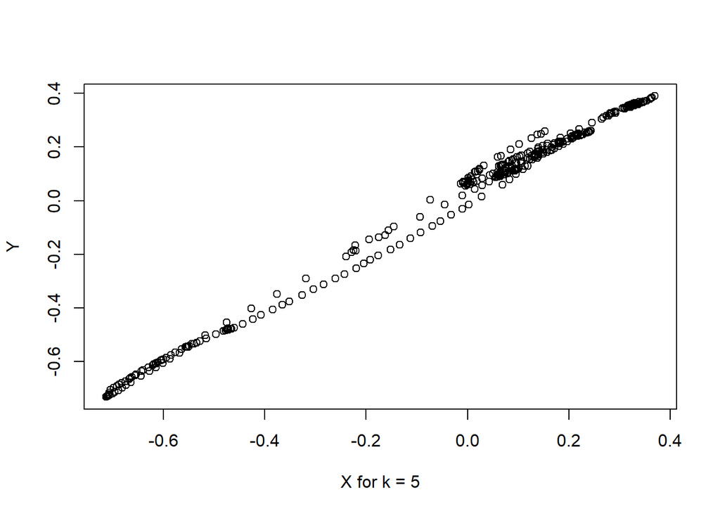

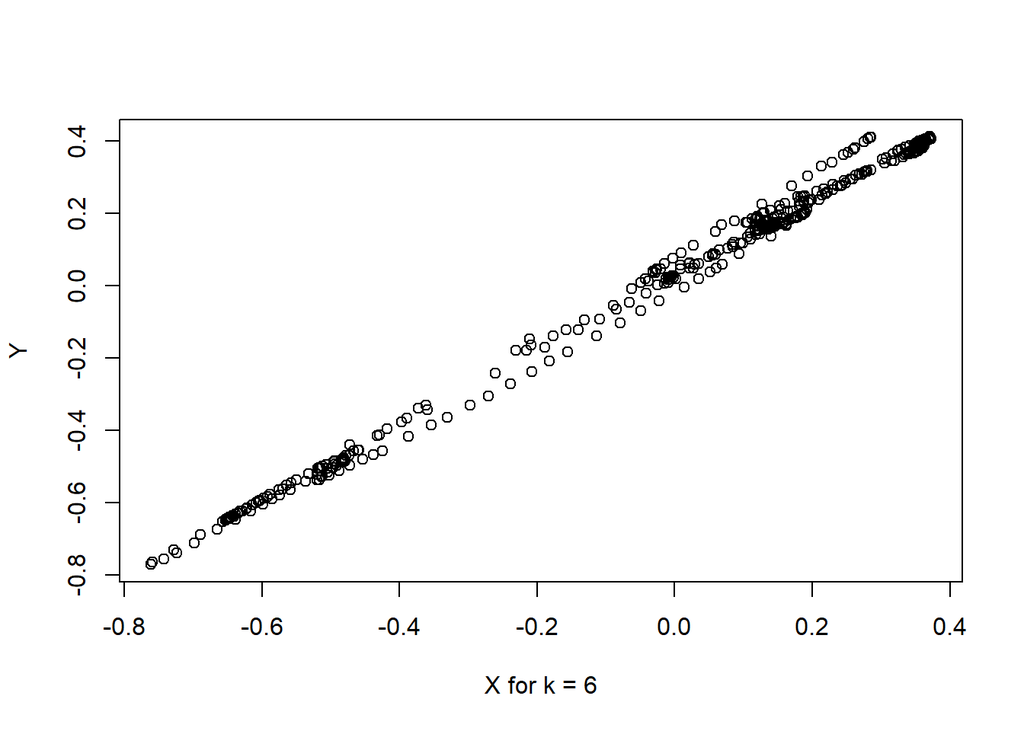

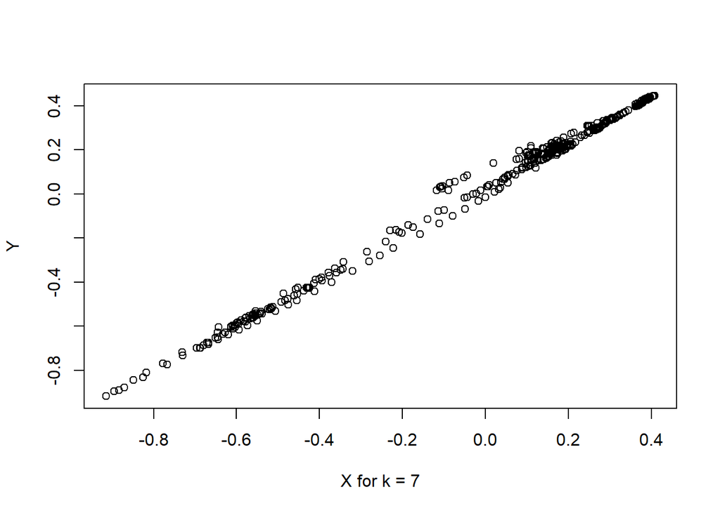

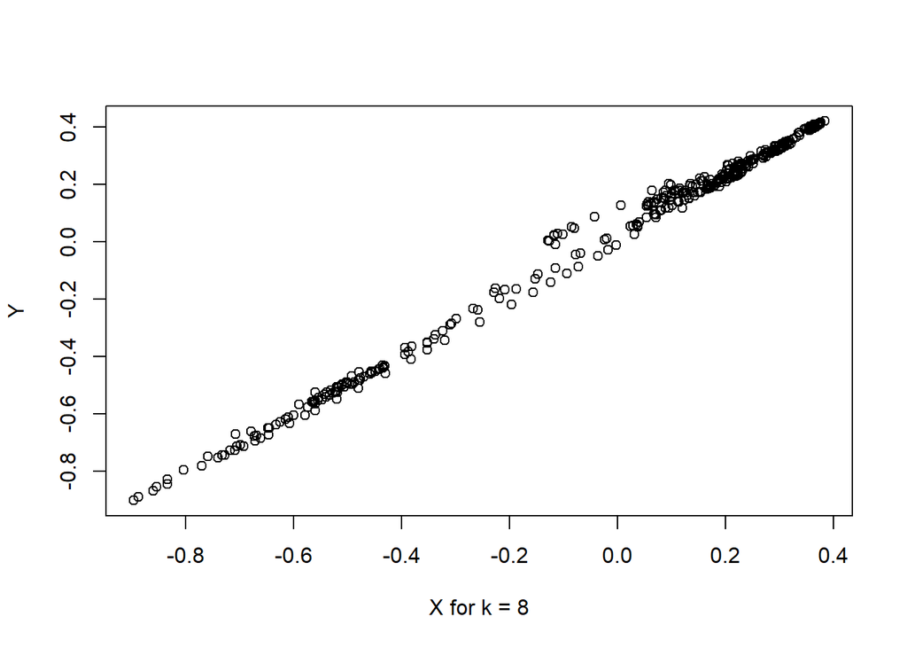

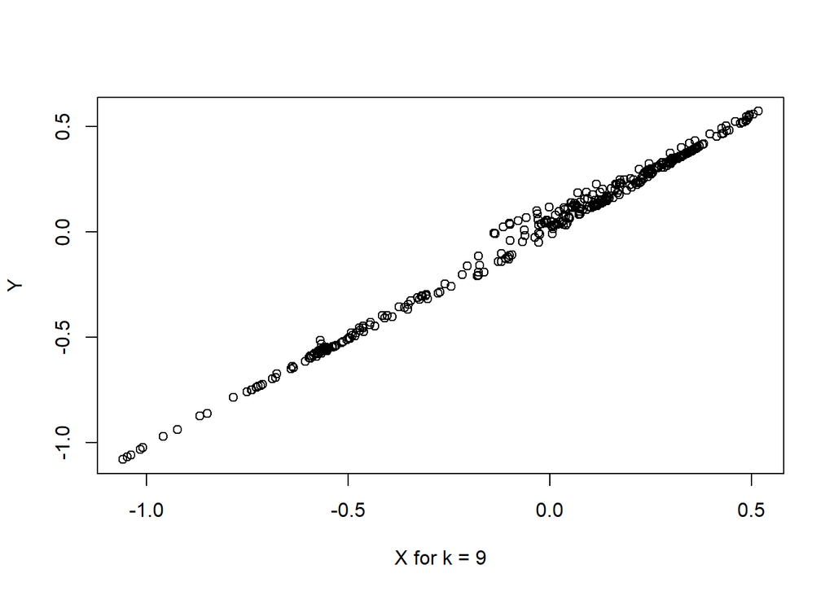

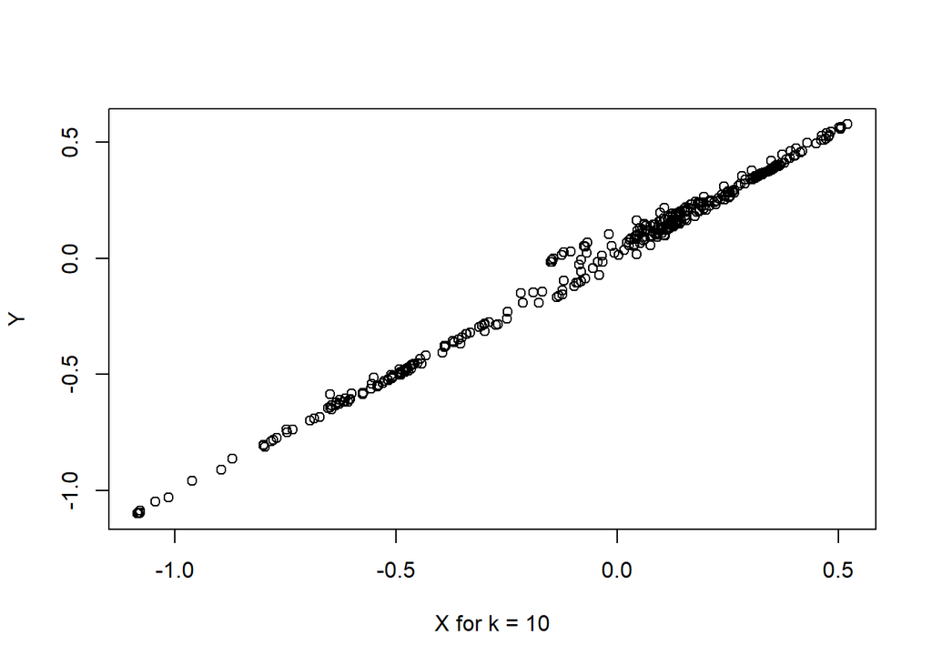

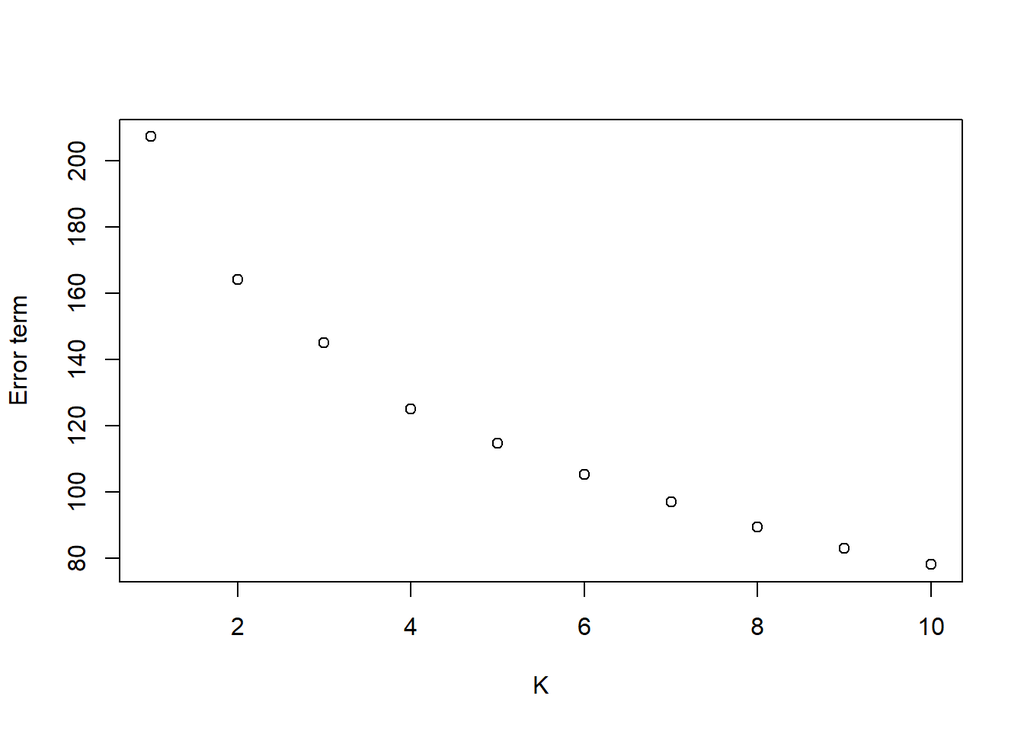

**Below are the plots of the PC1 scores and the eigenvectors.**

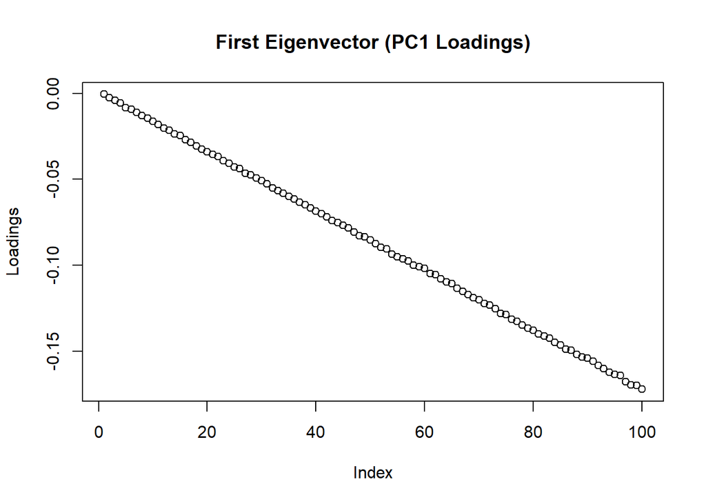

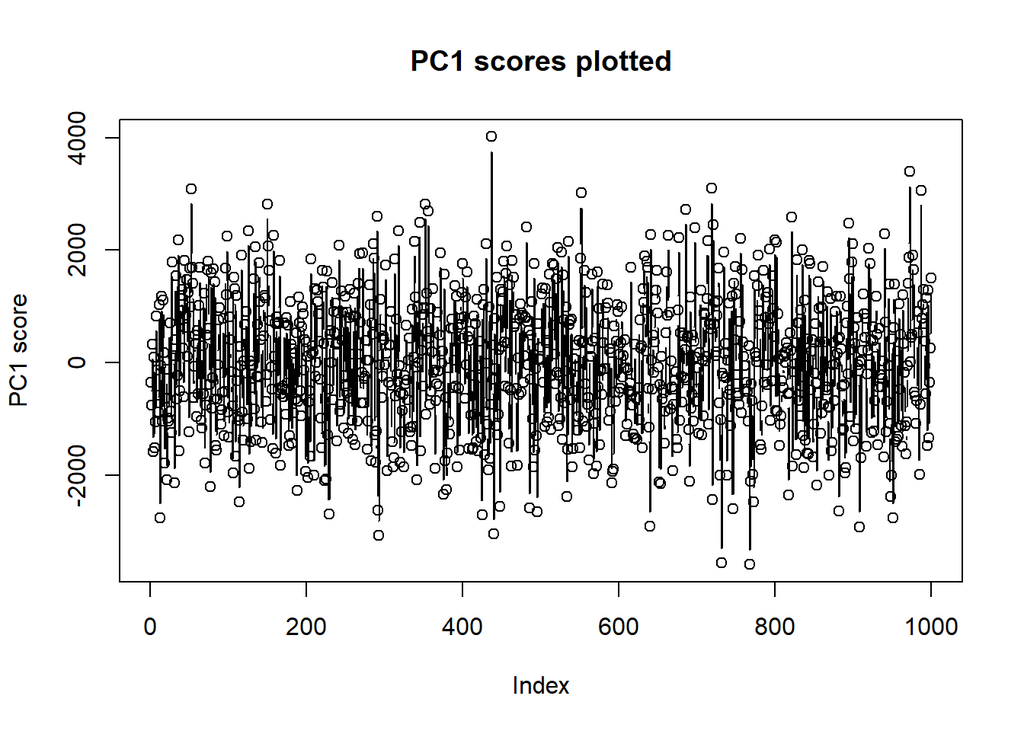

**The eigenvector plots seem to almost mimic the original image, just in the opposite direction. As the index increases,the features contribute more. For the PC1 scores, each index represents a feature and how far it extends in the new direction.**

## Image 4

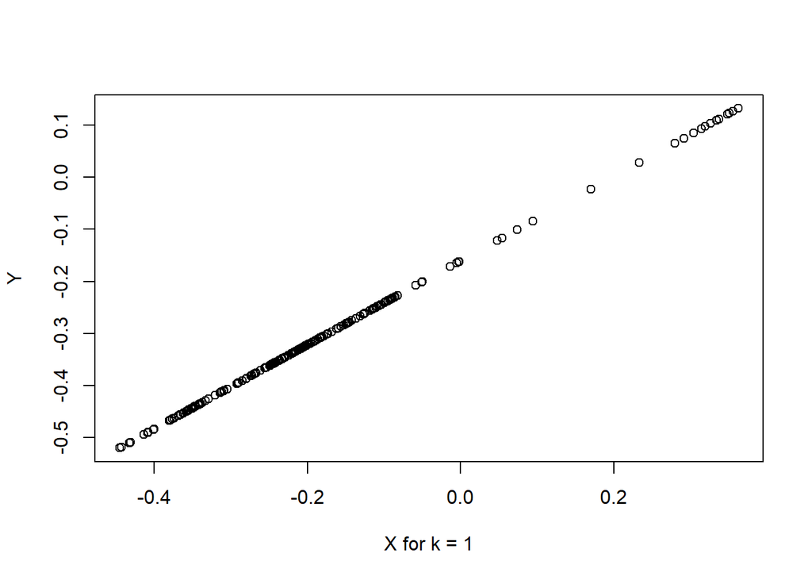

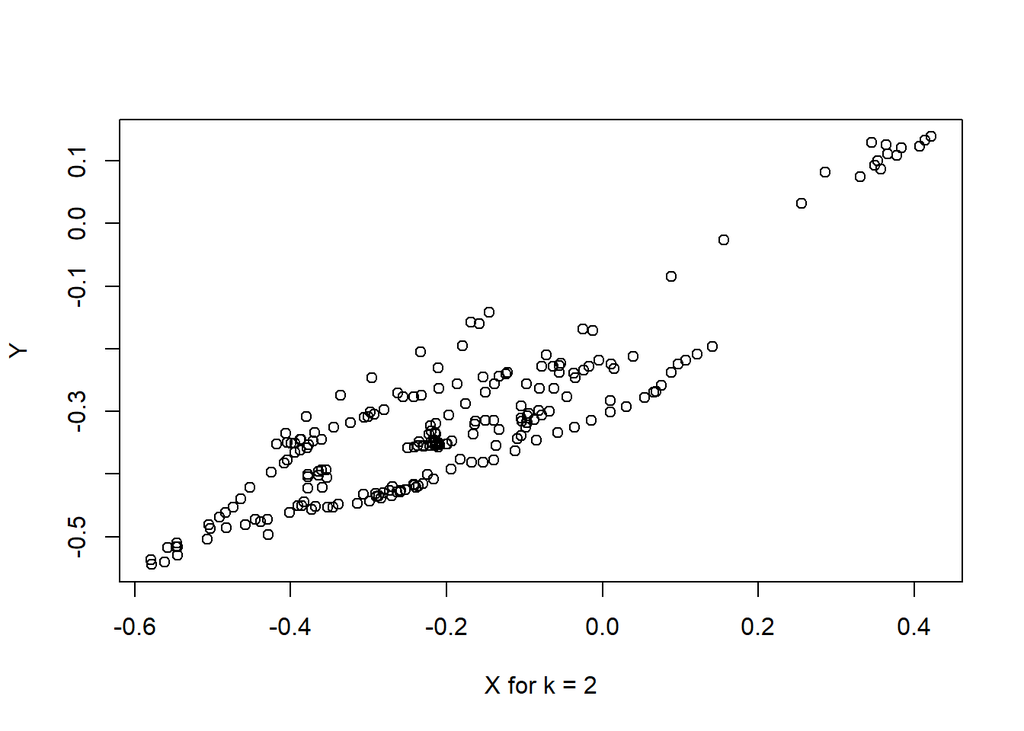

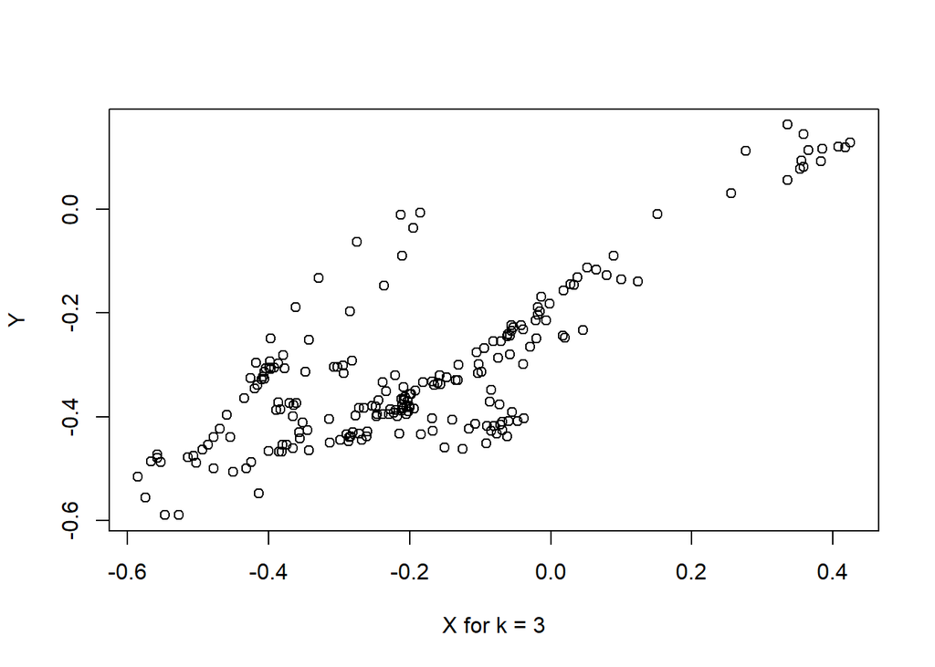

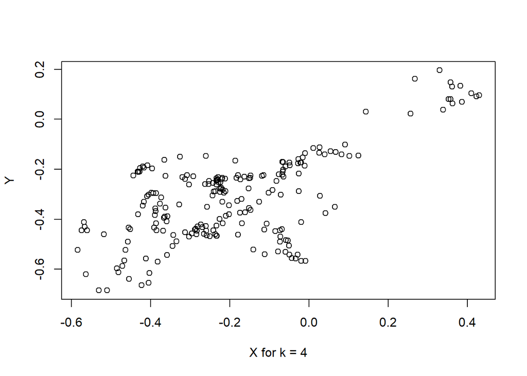

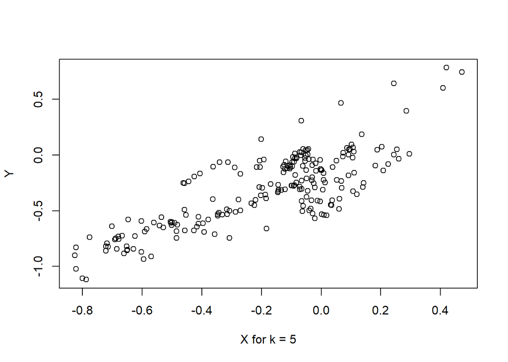

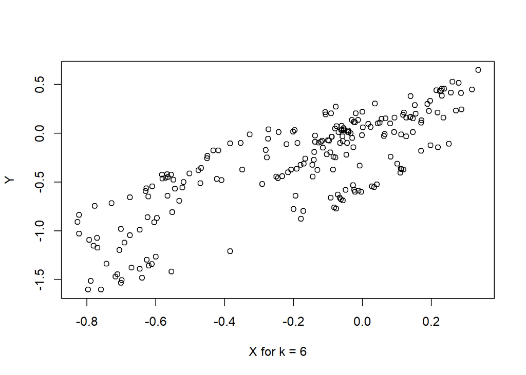

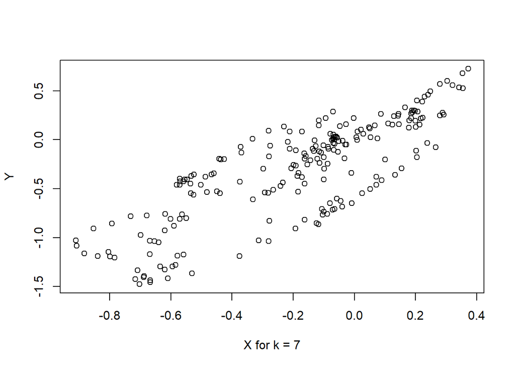

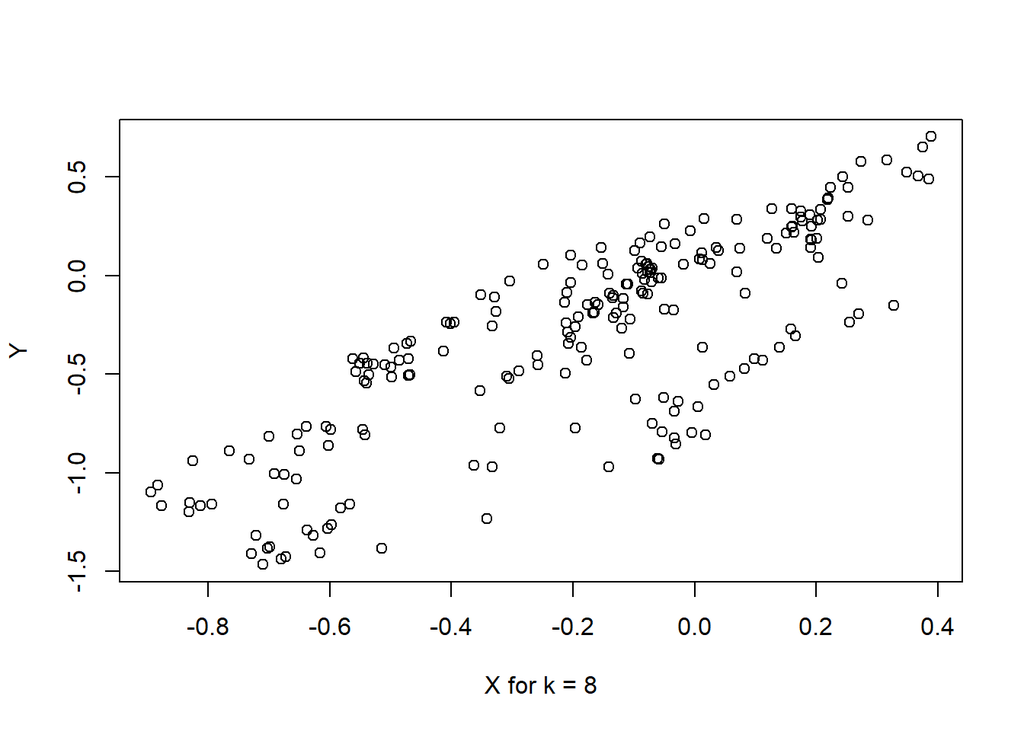

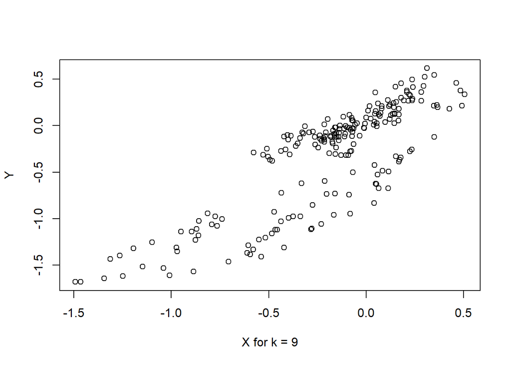

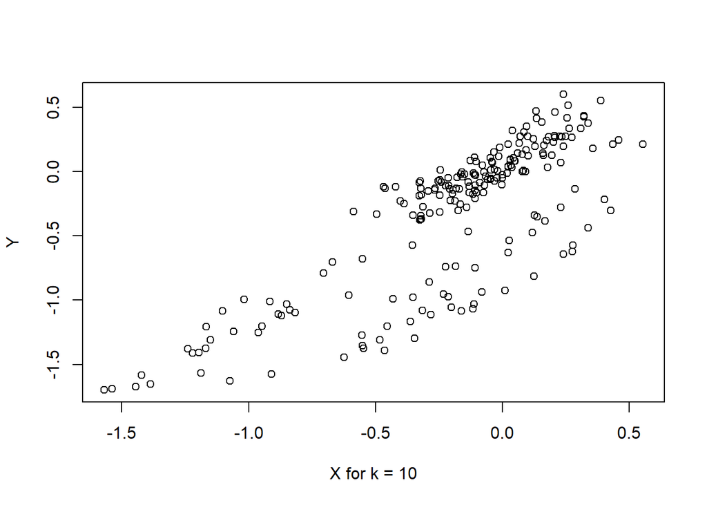

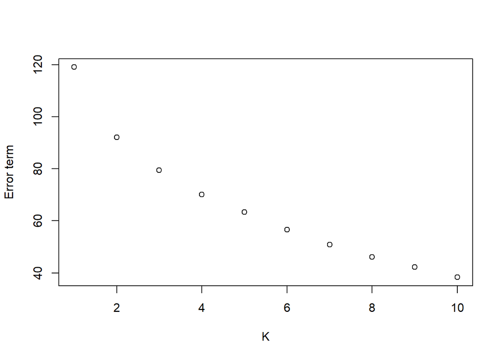

**I believe that k = 10 is the most accurate approximation to the original image, even though there is certainly a noticeable difference between the two of them.**

**The plots of the PC1 scores and the eigenvectors will be listed below.**

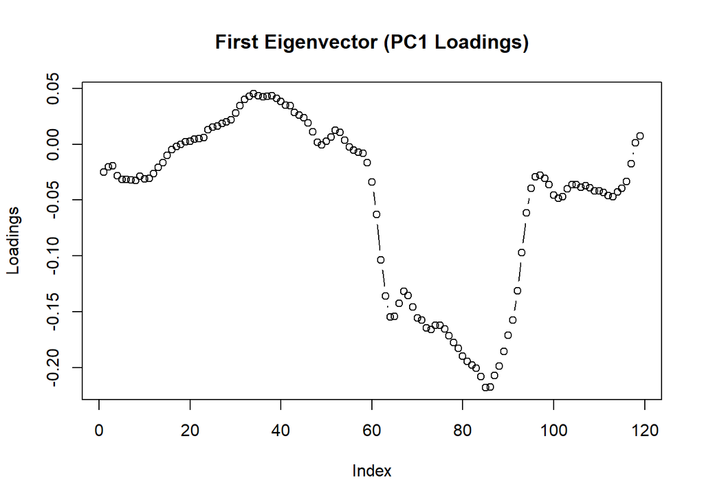

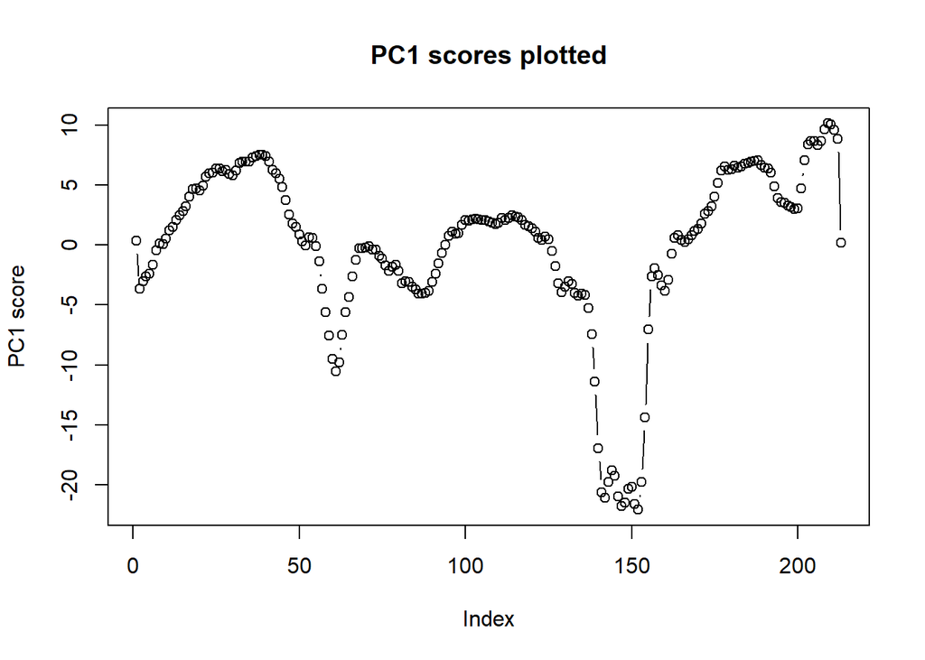

**Compared to the other images, the eigenvector and PC1 scores look different. Unlike the other images, the PC1 score plot almost models a smooth function, meaning features follow a recognizable pattern. This is the case with the eigenvector plot as well, as where the larger values that drive the component are similar to each other in index.**

**This concludes the presentation.** Thank you -Elijah Echevarria